# Baseball Walkout Song Analysis

February 07 2019

At this point, it’s cliche to say that watching a baseball game on TV is nothing like the in-person experience. But it’s a common refrain because it’s true.

To me, a key, but underrated, element that makes watching live more engaging is the sound of the stadium. It’s a mess of bats, cheering, PA announcements and music. A very intentional and orchestrated part of buzz is the walkout song for each player, a tradition you can trace back to a 1970’s Chicago White Sox [organist](https://www.nbcwashington.com/news/sports/Baseball-Walk-Up-Music--144150975.html) and a 1990’s Philadelphia Phillies [PR person](https://abcnews.go.com/Sports/mlb-walk-music-designated-hit/story?id=33437245).

Baseball walkout songs are each individually picked by the players. That is so unique for a major league sport and given the number of players in baseball, provides lots of data points for patters to emerge. I wanted to analyze the walkout music of the MLB 2018 regular season to answer a few questions.

- First, what are the overall musical trends?
- Next, when digging deeper, are there big differences when comparing teams or positions?
- Finally, a bit of a stretch but, is there any connection between performance and musical tastes?

Data was compiled from the [MLB website](https://www.mlb.com/entertainment/walk-up) (walkout songs), the [MLB stats API](https://appac.github.io/mlb-data-api-docs/) (hitting/pitching stats), and the [Last.FM API](https://www.last.fm/api) (artist genres). I used R for the analysis (check out my [GitHub](https://github.com/rtrent/Baseball_Walkout_Song_Analysis) for more deets).

## Overall Music Trends

To start with my first question, I’ve broken down the walkout music by genre, artist, and song.

### Walkout Song Genres

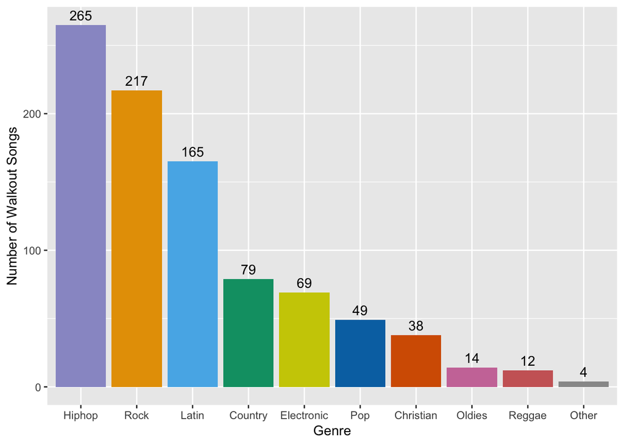

### Top Artists For Walkout Songs

| Artist | Number of Songs |
| --- | --- |
| Drake | 31 |
| Led Zeppelin | 18 |
| Imagine Dragons | 18 |
| Future | 15 |
| Bad Bunny | 13 |
| J Balvin | 12 |
| Ozuna | 11 |
| Lil Wayne | 11 |
| Migos | 10 |
| Kendrick Lamar | 9 |
| El Alfa | 9 |
| Daddy Yankee | 9 |
| Nicky Jam | 9 |
| Eric Church | 8 |
| Jason Aldean | 8 |
| AC/DC | 7 |
| BlocBoy JB | 7 |
| 2Pac | 6 |
| Cardi B | 6 |
| Gary Clark Jr. | 6 |
| Kid Ink | 6 |
| Skillet | 6 |
| The Notorious B.I.G. | 6 |
| Audioslave | 5 |
| Don Omar | 5 |

### Top Walkout Songs

| Title | Artist | Number |
| --- | --- | --- |
| God’s Plan | Drake | 6 |
| Look Alive (feat. Drake) | BlocBoy JB | 6 |
| Thunder | Imagine Dragons | 6 |
| Whatever It Takes | Imagine Dragons | 6 |
| X | Nicky Jam | 6 |
| Come Together | Gary Clark Jr. | 5 |
| I Like It | Cardi B | 5 |
| Bonita | J Balvin | 4 |
| No Diggity | Blackstreet | 4 |
| The Outsiders | Eric Church | 4 |
| Up Down (feat. Florida Georgia Line) | Morgan Wallen | 4 |
| When The Levee Breaks | Led Zeppelin | 4 |
| Bum Bum Tam Tam | MC Fioti, Future, J Balvin, Stefflon Don, Juan Magán | 4 |
| All Along the Watchtower | Jimi Hendrix | 3 |
| Believer | Imagine Dragons | 3 |
| Big Shot (with Travis Scott) | Kendrick Lamar | 3 |
| Bye Bye | Mozart La Para | 3 |
| Cochise | Audioslave | 3 |
| Creere | Tercer Cielo | 3 |
| Dirt On My Boots | Jon Pardi | 3 |
| Dura | Daddy Yankee | 3 |
| Fireman - Album Version (Edited) | Lil Wayne | 3 |
| HUMBLE. | Kendrick Lamar | 3 |
| Immigrant Song | Led Zeppelin | 3 |
| Kashmir | Led Zeppelin | 3 |
| Lo Que Yo Diga (Dema Ga Ge Gi Go Gu Remix) | El Alfa | 3 |
| Mi Cumpleaño | Secreto “El Famoso Biberon” | 3 |
| No Problem (feat. Lil Wayne & 2 Chainz) | Chance the Rapper | 3 |
| Now It’s Personal | Kid Ink | 3 |
| Pills & Automobiles | Chris Brown | 3 |
| Síguelo Bailando | Ozuna | 3 |
| Song of Deliverance | Zach Williams | 3 |
| Thunderstruck | AC/DC | 3 |
| Where the Party At | Jagged Edge | 3 |
| Chambea | Bad Bunny | 3 |

At a macro level, genres seem to be aligned with current musical tastes - the prominence of hip hop and the rise of Latin rap/pop - but looking at artists and songs, there are several bands part of the older generation of rock stars - Led Zeppelin and AC/DC. The latter at this point are staples in any stadium rotation looking to energize fans.

The weirdest walkout songs I found were: The [SpongeBob SquarePants theme](https://www.youtube.com/watch?v=r9L4AseD-aA) and what was called “Ric Flair Theme” (the walkout song for wrestler Ric Flair), also known as [“Also Sprach Zarathustra, Op. 30 (Obertura)](https://www.youtube.com/watch?v=dfe8tCcHnKY)“, composed by Richard Strauss.

## Deep Dive by Team and Position

Within each position or team, I expect there to be some interesting variations, but I’m not sure what we will see. Next, I have the team breakdowns.

### Walkout Song Genres by Team

| Team | Genre Hip-hop | Genre Rock | Genre Latin | Genre Country | Genre Electronic | Genre Pop | Genre Christian | Genre Oldies | Genre Reggae | Genre Other |
| --- | --- | --- | --- | --- | --- | --- | --- | --- | --- | --- |
| Arizona Diamondbacks | 28.1 | 28.1 | 9.4 | 6.2 | 6.2 | 6.2 | 12.5 | 3.1 | 0.0 | 0.0 |
| Atlanta Braves | 31.0 | 24.1 | 17.2 | 10.3 | 6.9 | 0.0 | 3.4 | 0.0 | 6.9 | 0.0 |
| Baltimore Orioles | 26.1 | 34.8 | 13.0 | 13.0 | 0.0 | 0.0 | 8.7 | 4.3 | 0.0 | 0.0 |
| Boston Red Sox | 25.0 | 33.3 | 4.2 | 12.5 | 16.7 | 4.2 | 4.2 | 0.0 | 0.0 | 0.0 |
| Chicago Cubs | 32.1 | 28.6 | 21.4 | 3.6 | 10.7 | 0.0 | 0.0 | 3.6 | 0.0 | 0.0 |
| Chicago White Sox | 15.6 | 18.8 | 37.5 | 6.2 | 3.1 | 6.2 | 9.4 | 3.1 | 0.0 | 0.0 |
| Cincinnati Reds | 30.0 | 26.7 | 23.3 | 6.7 | 6.7 | 0.0 | 0.0 | 3.3 | 0.0 | 3.3 |
| Cleveland Indians | 32.3 | 22.6 | 16.1 | 6.5 | 12.9 | 3.2 | 3.2 | 0.0 | 3.2 | 0.0 |
| Colorado Rockies | 32.4 | 37.8 | 13.5 | 2.7 | 8.1 | 2.7 | 0.0 | 2.7 | 0.0 | 0.0 |
| Detroit Tigers | 20.7 | 17.2 | 20.7 | 13.8 | 10.3 | 6.9 | 6.9 | 3.4 | 0.0 | 0.0 |
| Houston Astros | 39.3 | 14.3 | 10.7 | 10.7 | 7.1 | 7.1 | 3.6 | 3.6 | 0.0 | 3.6 |
| Kansas City Royals | 21.7 | 30.4 | 30.4 | 8.7 | 0.0 | 4.3 | 0.0 | 4.3 | 0.0 | 0.0 |
| Los Angeles Angels | 33.3 | 25.0 | 13.9 | 2.8 | 13.9 | 5.6 | 2.8 | 0.0 | 2.8 | 0.0 |
| Los Angeles Dodgers | 28.1 | 28.1 | 9.4 | 12.5 | 9.4 | 9.4 | 0.0 | 0.0 | 3.1 | 0.0 |
| Miami Marlins | 35.3 | 23.5 | 17.6 | 11.8 | 5.9 | 0.0 | 5.9 | 0.0 | 0.0 | 0.0 |
| Milwaukee Brewers | 29.3 | 22.0 | 17.1 | 12.2 | 4.9 | 7.3 | 2.4 | 2.4 | 0.0 | 2.4 |
| Minnesota Twins | 25.0 | 18.8 | 31.2 | 6.2 | 6.2 | 12.5 | 0.0 | 0.0 | 0.0 | 0.0 |
| New York Mets | 25.6 | 37.2 | 11.6 | 9.3 | 7.0 | 0.0 | 4.7 | 2.3 | 2.3 | 0.0 |
| New York Yankees | 44.0 | 24.0 | 12.0 | 8.0 | 0.0 | 12.0 | 0.0 | 0.0 | 0.0 | 0.0 |
| Oakland Athletics | 32.4 | 26.5 | 5.9 | 11.8 | 8.8 | 5.9 | 2.9 | 0.0 | 5.9 | 0.0 |
| Philadelphia Phillies | 20.0 | 16.0 | 20.0 | 12.0 | 8.0 | 8.0 | 16.0 | 0.0 | 0.0 | 0.0 |
| Pittsburgh Pirates | 22.7 | 18.2 | 13.6 | 13.6 | 13.6 | 4.5 | 4.5 | 4.5 | 4.5 | 0.0 |
| San Diego Padres | 23.1 | 26.9 | 15.4 | 3.8 | 3.8 | 11.5 | 3.8 | 3.8 | 7.7 | 0.0 |
| San Francisco Giants | 4.5 | 40.9 | 13.6 | 9.1 | 9.1 | 9.1 | 13.6 | 0.0 | 0.0 | 0.0 |
| Seattle Mariners | 37.5 | 25.0 | 12.5 | 8.3 | 12.5 | 4.2 | 0.0 | 0.0 | 0.0 | 0.0 |
| St. Louis Cardinals | 20.8 | 25.0 | 16.7 | 16.7 | 8.3 | 8.3 | 0.0 | 0.0 | 4.2 | 0.0 |
| Tampa Bay Rays | 20.5 | 25.6 | 23.1 | 7.7 | 5.1 | 7.7 | 7.7 | 0.0 | 0.0 | 2.6 |
| Texas Rangers | 32.0 | 0.0 | 20.0 | 24.0 | 8.0 | 12.0 | 0.0 | 4.0 | 0.0 | 0.0 |
| Toronto Blue Jays | 22.2 | 37.0 | 11.1 | 7.4 | 7.4 | 11.1 | 3.7 | 0.0 | 0.0 | 0.0 |
| Washington Nationals | 24.0 | 20.0 | 12.0 | 8.0 | 16.0 | 8.0 | 8.0 | 0.0 | 4.0 | 0.0 |

This first chart is a bit unwieldy. It’s a little to large to get a sense of the whole all at once, but it’s good for referencing specifics. I’ve also created a visual representation below. This has it’s own limitations, but should be easier for spotting trends.

### Walkout Song Genres by Team - Stacked Bar Chart

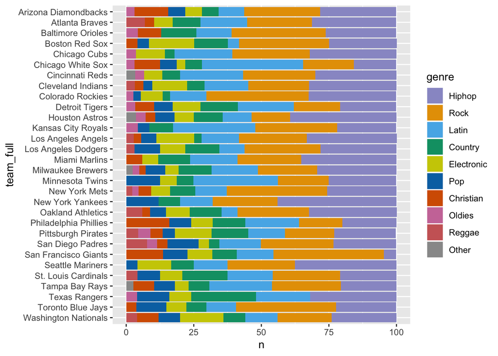

Some of the more interesting things I can see from this are:

- The New York Yankees are the most hip-hop team
- The San Francisco Giants are the least hip-hop, but also the most rock
- The Texas Rangers have zero players that use rock music (suprising since its the overall #2 genre), but also the most country
- Boston is the most electronic
- Philly is the most Christian
- The Padres are the most reggae

Overall there are not any apparent trends. I do see somewhat of a divide between the coasts and the center of the country when it comes to country music. These patterns are obviously noisey because players don’t necessarily hail from the city/region where they play. But even if an individual player has different tastes, at the team level it seems the culture of the city does seem to break through.

Next, the breakdown by field position.

### Walkout Song Genres by Position Played

| Position | Genre Hip-hop | Genre Rock | Genre Latin | Genre Country | Genre Electronic | Genre Pop | Genre Christian | Genre Oldies | Genre Reggae | Genre Other |
| --- | --- | --- | --- | --- | --- | --- | --- | --- | --- | --- |
| 1B | 26.7 | 24.4 | 13.3 | 11.1 | 11.1 | 4.4 | 4.4 | 4.4 | 0.0 | 0.0 |
| 2B | 24.5 | 17.0 | 20.8 | 5.7 | 13.2 | 7.5 | 3.8 | 5.7 | 1.9 | 0.0 |
| 3B | 29.8 | 19.1 | 19.1 | 10.6 | 8.5 | 4.3 | 4.3 | 2.1 | 2.1 | 0.0 |
| C | 26.7 | 16.0 | 20.0 | 13.3 | 5.3 | 5.3 | 6.7 | 4.0 | 2.7 | 0.0 |
| CF | 39.0 | 6.8 | 16.9 | 3.4 | 8.5 | 13.6 | 8.5 | 1.7 | 1.7 | 0.0 |
| LF | 46.0 | 10.0 | 20.0 | 8.0 | 4.0 | 8.0 | 2.0 | 2.0 | 0.0 | 0.0 |
| P | 22.2 | 37.0 | 11.0 | 11.2 | 7.4 | 4.1 | 3.8 | 0.8 | 1.9 | 0.5 |
| RF | 31.0 | 19.0 | 19.0 | 0.0 | 13.8 | 12.1 | 1.7 | 0.0 | 0.0 | 3.4 |
| SS | 36.2 | 12.1 | 32.8 | 6.9 | 1.7 | 3.4 | 6.9 | 0.0 | 0.0 | 0.0 |

` This table is easier to digest than the previous one, but I’ve added another visual to help make differences more apparent.

### Walkout Song Genres by Position Played - Clustered Bar Chart

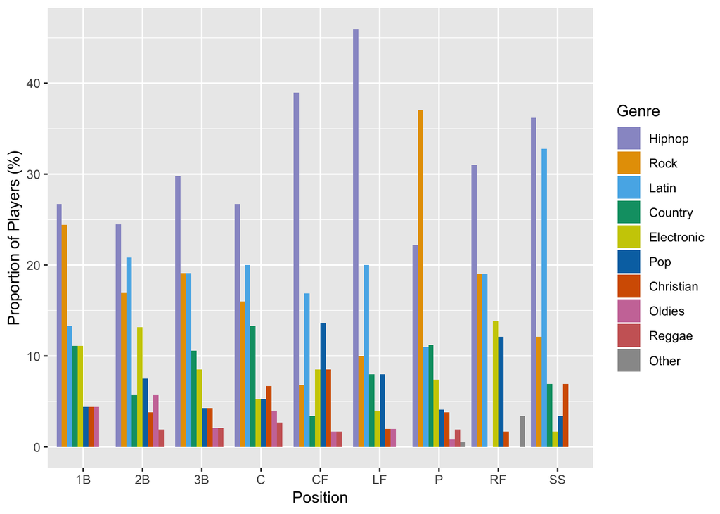

Here I see some more curious trends. They’re interesting, but there is no clear explanation for why.

- Left Fielders are the most hip-hop
- Pitchers are the most rock by a sizable margin
- Shortstops are the most Latin
- Christian is sprinkled throughout, but it’s 5x more prevelent in Center Field than the other two outfielders
- Right Field has no country (and overall country is much lower for the outfield than infield)

I’m not sure what to do with this information regarding differences by position. It’s interesting, but nothing more than that. There is one trend that I can offer a partial explanation for. The prominence of Latin music with shortstops may be because half of the sample is made up of players born in Latin America.

## Relationship Between Performance and Music

Finally, the final and most speculative question of this analysis. Could there be any kind of link between music and performance? Since this is not set up as a randomized experiment, we could never say that the music *caused* any of this performance. We can test to see if theres a relationship between the two that can’t just be explained by randomness.

I’m analyzing four statistics, two for batting and two for pitching. In each case I’ve picked a more complicated one and something more tangible.

- Batting
- On Base Percentage Plus Slugging (OPS) - The addition of On Base Percentage (the proportion of at-bats a player is on base) and Slugging Percentage (the average number of bases a player gets each at-bat) - the higher the better
- Home Runs (HR) - a more straightforward way to judge a batter - home runs are good, so the more the better
- Pitching
- Walks and Hits Per Inning Pitched (WHIP) - How often a pitcher allows a player to get on base - the lower the batter
- Strike Outs - More straight forward for pitching - strike outs are the best outcome for a pitcher, so the more the better

OPS and WHIP are a bit complicated, but modern baseball analysts consider these the gold standard batting and pitching stats to evaluate players on.

For my interpretation, I’ve created a visual representation of each distribution by genre. Following that I’ve run an ANOVA test to determine if any of the relationships are statistically significant. ANOVA will not tell us which genre is significantly higer or lower, just that the relationship overall is not explainable by chance alone. It does this by comparing variance of each sub-group to the variance of the data overall.

I’ve removed the less frequent genres, oldies, reggae and other since there are too few observations to draw meaningful conclusions about their distributions (i.e. it may mess up our statistical analysis). Small group sizes also don’t work very well with ANOVA.

### On Base Plus Slugging (OPS) Distribution by Genre

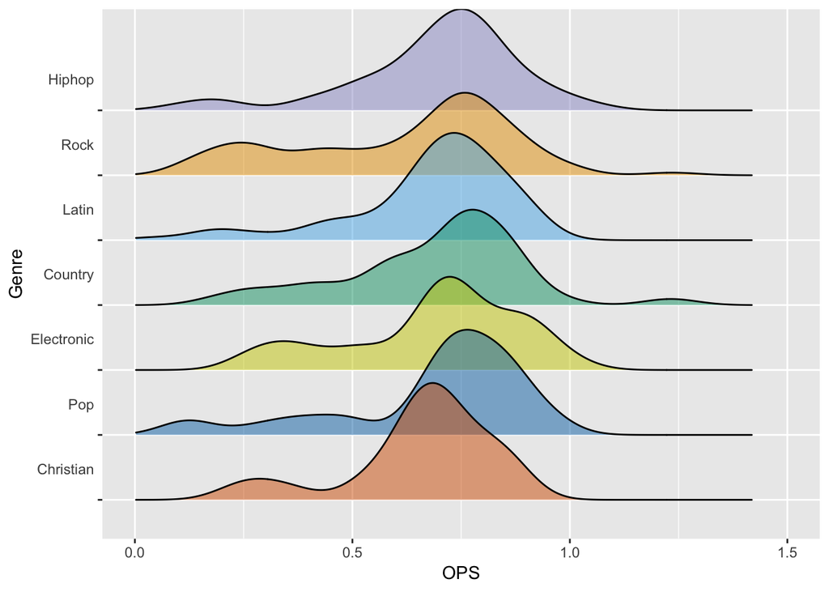

### Home Run Distributin by Genre

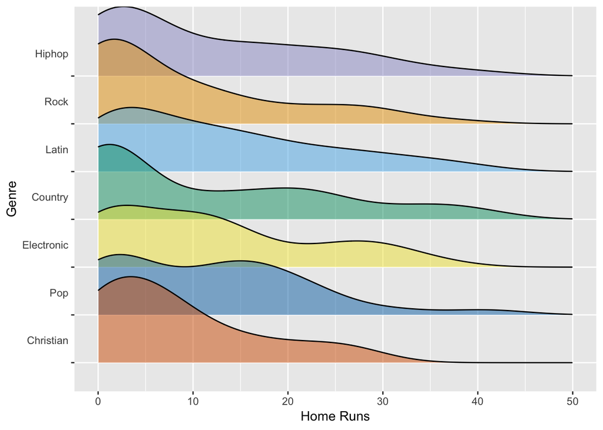

### Walks and Hits per Inning Pitched (WHIP) Distribution by Genre

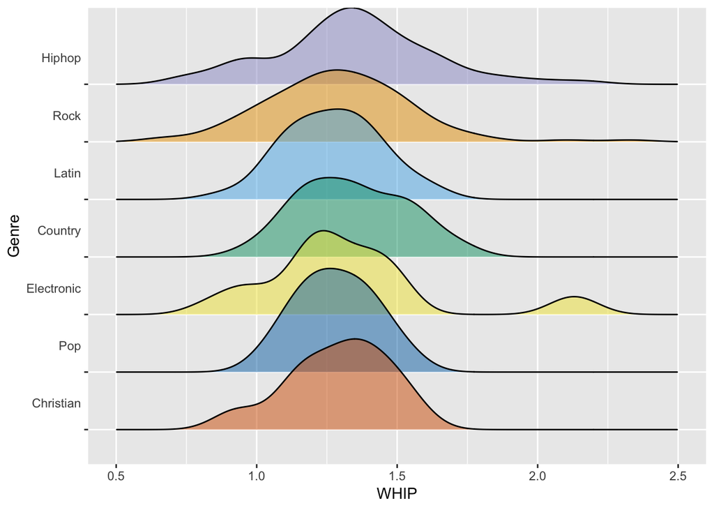

### Strike Out Distribution by Genre

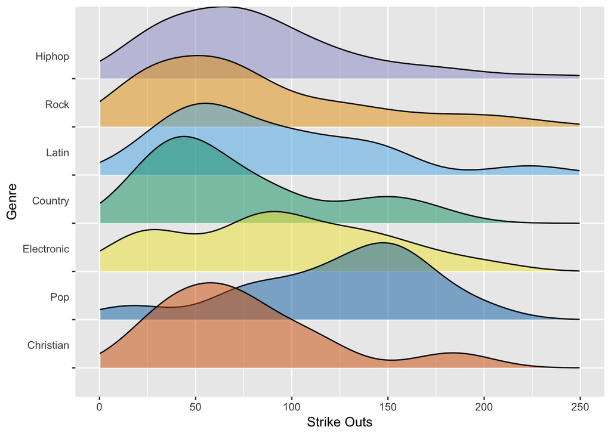

From these visuals, OPS and WHIP seem very consistent across genres. I would not suspect there was any relationship there. For HR and SO though, there is some difference. Pop and Electronic seem to have more of the distribution area on the right. Country also has a thicker right tail. It’s important to note though that these genres have smaller samples sizes, so that may be playing a role in the distribution we are seeing.

To confirm the suspicion that there are no relationships present, we can turn to statistical tools available in R. As previously stated, I’m using ANOVA testing. For reference, I’ve just made a table of each stats mean and standard deviation by genre. These two summary statistics are the components of the ANOVA test. The R function I’ve run will automatically provide a p value which we can interpret.

### Summary Table and ANOVA Tests for Stats+Genre Relationship

| Genre | OPS Mean | OPS StDev | HR Mean | HR StDev | WHIP Mean | WHIP StDev | SO Mean | SO StDev |
| --- | --- | --- | --- | --- | --- | --- | --- | --- |
| Christian | 0.66 | 0.16 | 8.12 | 8.48 | 1.29 | 0.18 | 75.27 | 45.37 |
| Country | 0.69 | 0.21 | 11.92 | 12.76 | 1.34 | 0.19 | 72.69 | 46.55 |
| Electronic | 0.69 | 0.20 | 11.85 | 10.95 | 1.32 | 0.31 | 93.13 | 52.80 |
| Hiphop | 0.69 | 0.19 | 11.76 | 12.32 | 1.34 | 0.28 | 83.54 | 54.29 |
| Latin | 0.68 | 0.18 | 11.12 | 10.78 | 1.27 | 0.17 | 87.35 | 52.28 |
| Pop | 0.69 | 0.22 | 11.44 | 10.24 | 1.28 | 0.14 | 123.33 | 48.89 |
| Rock | 0.62 | 0.25 | 8.75 | 10.16 | 1.29 | 0.26 | 79.77 | 57.62 |

### ANOVA: Genre vs OPS

```
##              Df Sum Sq Mean Sq F value Pr(>F)
## genre         6   0.35 0.05829   1.398  0.214
## Residuals   464  19.34 0.04169
```

### ANOVA: Genre vs HR

```
##              Df Sum Sq Mean Sq F value Pr(>F)
## genre         6    814   135.7   1.075  0.376
## Residuals   464  58567   126.2
```

### ANOVA: Genre vs WHIP

```
##              Df Sum Sq Mean Sq F value Pr(>F)
## genre         6  0.229 0.03820   0.623  0.712
## Residuals   292 17.894 0.06128
```

### ANOVA: Genre vs SO

```
##              Df Sum Sq Mean Sq F value Pr(>F)
## genre         6  28106    4684   1.607  0.145
## Residuals   292 851053    2915
```

Well, this was an excessive amount of calculation to conclude that none of the relationships are significant. Strike outs came the closest, which makes sense looking at our visualization again.

At this point, I have to reject my hypothesis there was any relationship between a players genre of walkout song and their performance. Despite not getting any evidence for my idea, this exercise was really interesting and, as the scientific community agrees, it’s important to publish [negative results](https://www.nature.com/articles/d41586-017-07325-2).

## Conclusion

The highlights of the groundbreaking analysis I’ve brought you today:

- Hip-hop and Drake are really popular, but so are modern and classic rock bands.
- The Giants don’t like hip-hop, but not as much as the Rangers don’t like rock.
- Pitchers like rock and shortstops like Latin music, but don’t even think about playing country for outfielders.
- There is no relationship between the genre of a player’s walkout song and their performance (batting or pitching).

To close, I will share my hypothetical [walkout song](https://www.youtube.com/watch?v=vuyxX5P5Xug).